# Principal Component Analysis

Dataset comp$completeObs

This dataset contains 42 individuals and 34 variables, 9 quantitative variables are considered as illustrative, 5 qualitative variables are considered as illustrative.

### 1. Study of the outliers

The analysis of the graphs does not detect any outlier.

### 2. Inertia distribution

The inertia of the first dimensions shows if there are strong relationships between variables and suggests the number of dimensions that should be studied.

The first two dimensions of PCA express **35.11%** of the total dataset inertia ; that means that 35.11% of the individuals (or variables) cloud total variability is explained by the plane. This is an intermediate percentage and the first plane represents a part of the data variability. This value is greater than the reference value that equals **25.39%**, the variability explained by this plane is thus significant (the reference value is the 0.95-quantile of the inertia percentages distribution obtained by simulating 1226 data tables of equivalent size on the basis of a normal distribution).

From these observations, it may be interesting to consider the next dimensions which also express a high percentage of the total inertia.

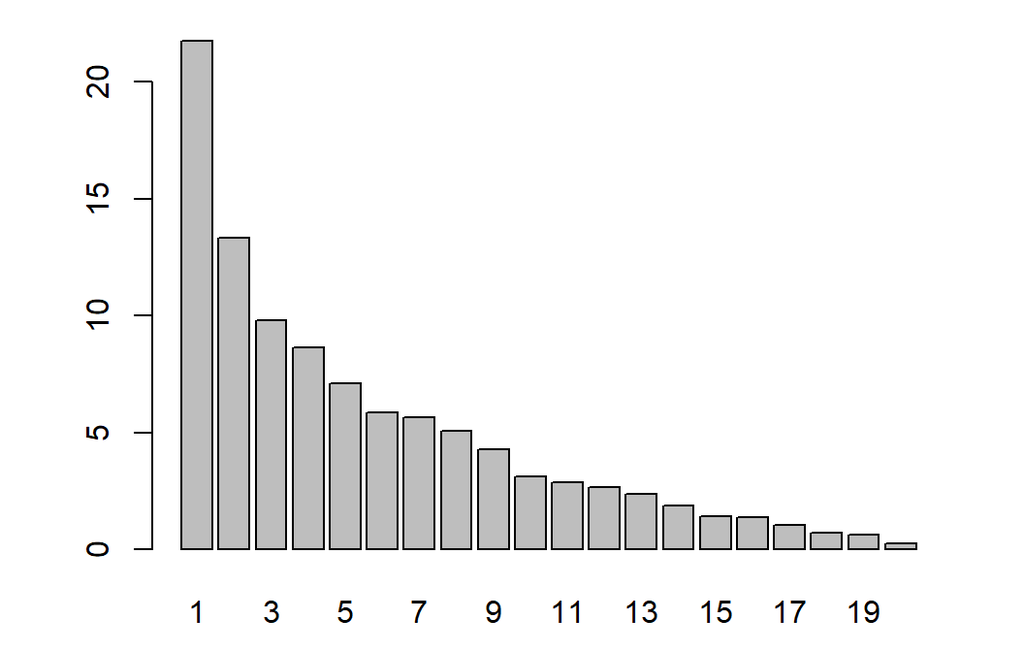

**Figure 2 - Decomposition of the total inertia on the components of the PCA**

An estimation of the right number of axis to interpret suggests to restrict the analysis to the description of the first 2 axis. These axis present an amount of inertia greater than those obtained by the 0.95-quantile of random distributions (35.11% against 25.39%). This observation suggests that only these axis are carrying a real information. As a consequence, the description will stand to these axis.

### 3. Description of the plane 1:2

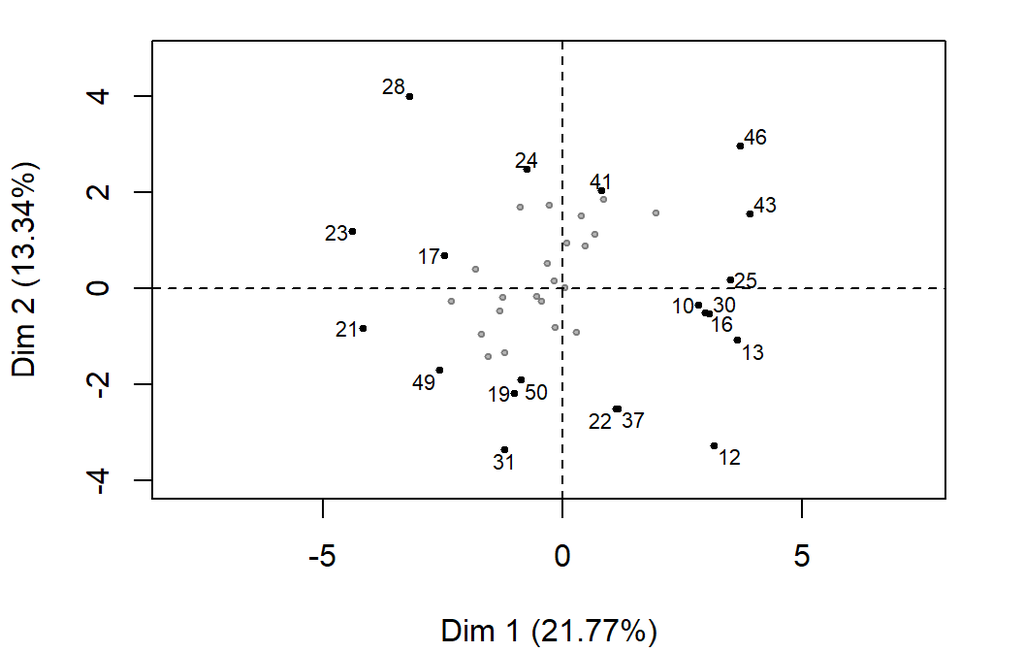

**Figure 3.1 - Individuals factor map (PCA)** *The labeled individuals are those with the higher contribution to the plane construction.*

The Wilks test p-value indicates which variable factors are the best separated on the plane (i.e. which one explain the best the distance between individuals).

```
 Dyslipidemia    Hbpressure      Diabetes PerineuralInv      ProstExt
    0.1375136     0.1574256     0.7245308     0.8830162     0.9164418
```

The best qualitative variable to illustrate the distance between individuals on this plane is : *Dyslipidemia*.

[output not shown]

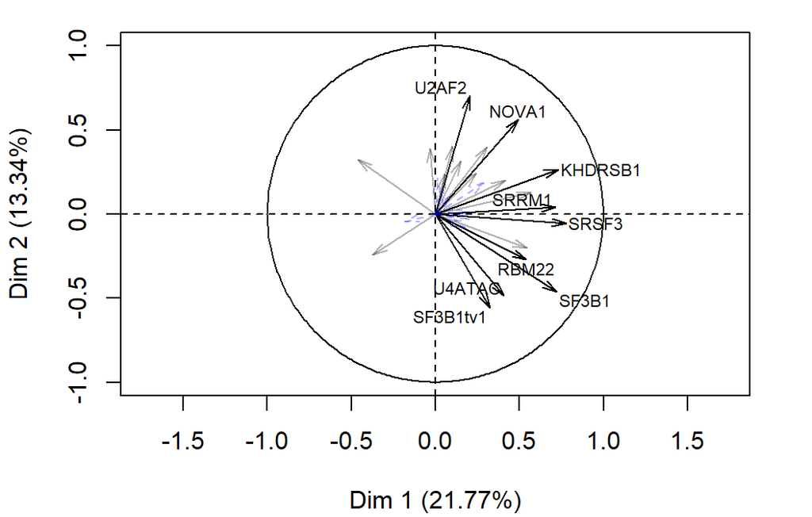

**Figure 3.3 - Variables factor map (PCA)** *The variables in black are considered as active whereas those in blue are illustrative.* *The labeled variables are those the best shown on the plane.*

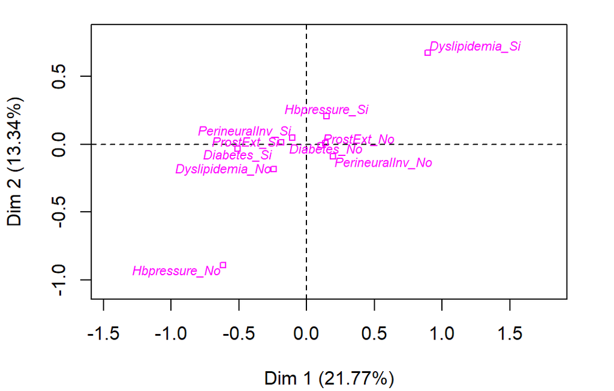

**Figure 3.4 - Qualitative factor map (PCA)** *The labeled factors are those the best shown on the plane.*

The group in which the individuals *46*, *12*, *43*, *25*, *13*, *30* and *10* stand (characterized by a positive coordinate on the axis) is sharing :

- high values for the variables *KHDRSB1*, *SRSF3*, *SRRM1*, *SF3B1*, *NOVA1*, *RBM3*, *snRNP200*, *sst5TMD4exp* and *RNU11* (variables are sorted from the strongest).
- low values for the variable *SFPQ*.

- high values for the variable *SRSF6*.
- low values for the variables *SRRM1*, *RBM22*, *RNU11*, *SRSF3*, *U4ATAC*, *SF3B1tv1* and *SF3B1* (variables are sorted from the weakest).

The group in which the individuals *49*, *31*, *22*, *19*, *37* and *50* stand (characterized by a negative coordinate on the axis) is sharing :

- low values for the variables *NOVA1* and *U2AF2* (variables are sorted from the weakest).

### 4. Classification

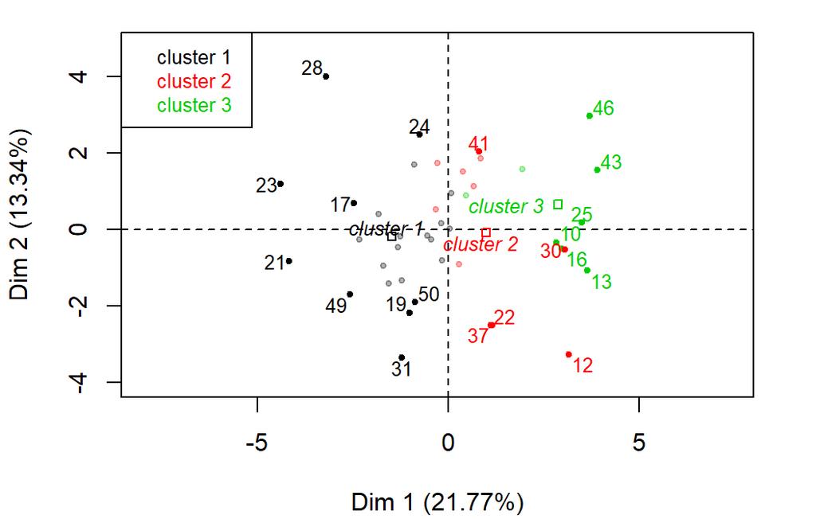

**Figure 4 - Ascending Hierarchical Classification of the individuals.** *The classification made on individuals reveals 3 clusters.*

The **cluster 2** is made of individuals such as *12*, *22*, *30*, *37* and *41*. This group is characterized by :

- high values for the variables *snRNP200*, *RNU11*, *PSA*, *PCA3exp* and *U4ATAC* (variables are sorted from the strongest).
- low values for the variable *PRPF40A*.

The **cluster 3** is made of individuals such as *10*, *13*, *16*, *25*, *43* and *46*. This group is characterized by :

- high values for the variables *NOVA1*, *SRSF3*, *SF3B1*, *SRRM1*, *PRPF40A*, *KHDRSB1*, *SRRM4* and *RBM3* (variables are sorted from the strongest).
- low values for the variable *SRSF6*.

## Annexes

```r
dimdesc(res, axes = 1:2)
```

```
$Dim.1
$Dim.1$quanti
         correlation      p.value
SRSF3      0.7766881 1.485406e-09
KHDRSB1    0.7299179 4.137037e-08
SF3B1      0.7219755 6.804966e-08
SRRM1      0.7137321 1.120739e-07
RBM3       0.5668786 9.076426e-05
RNU11      0.5458527 1.847889e-04
RBM22      0.5415287 2.126477e-04
NOVA1      0.4927066 9.170124e-04
snRNP200   0.4145248 6.346039e-03
U4ATAC     0.4096260 7.061987e-03
SF3B1tv1   0.3233218 3.674429e-02
PRPF8      0.3075014 4.759291e-02
SFPQ      -0.3731710 1.492935e-02
SRSF6     -0.4619014 2.074762e-03


$Dim.2
$Dim.2$quanti
         correlation      p.value
U2AF2      0.7054071 1.823313e-07
NOVA1      0.5630377 1.037230e-04
PRPF40A    0.4002745 8.623865e-03
PRPF8      0.3951557 9.598270e-03
RAVER1     0.3901110 1.064944e-02
SRSF6      0.3232286 3.680172e-02
RNU12      0.3131793 4.343501e-02
SF3B1     -0.4623982 2.048828e-03
U4ATAC    -0.4868162 1.078312e-03
SF3B1tv1  -0.5561708 1.311412e-04
```

**Figure 5 - List of variables characterizing the dimensions of the analysis.**

```r
res.hcpc$desc.var
```

```
$test.chi2
     p.value df

$quanti.var
              Eta2      P-value
snRNP200 0.5806693 4.363695e-08
NOVA1    0.4140049 2.978051e-05
SRSF3    0.3999489 4.727928e-05
SRRM1    0.3725260 1.130099e-04
KHDRSB1  0.3481772 2.374245e-04
SF3B1    0.3356456 3.441887e-04
RNU11    0.3246044 4.746629e-04
PRPF40A  0.3159023 6.092618e-04
RBM3     0.3017813 9.074730e-04
SRRM4    0.1825205 1.964714e-02
PSA      0.1616802 3.209886e-02
U4ATAC   0.1606786 3.285503e-02
PCA3exp  0.1542798 3.809959e-02
RBM22    0.1514642 4.065075e-02

$quanti
$quanti$`1`
            v.test Mean in category Overall mean sd in category
SFPQ      2.112467     8.253545e+03      6384.38   6.632756e+03
U4ATAC   -2.164860     1.644522e+01        21.36   1.142463e+01
U2AF2    -2.347709     1.677840e+06   1906268.05   6.282352e+05
NOVA1    -2.381107     1.023059e+06   1302948.48   6.551913e+05
RBM22    -2.463829     7.021115e+06   7753793.21   1.720042e+06
SRSF3    -2.932522     1.994791e+07  23963232.31   6.244058e+06
SF3B1    -2.935672     1.032223e+07  12855204.57   4.236472e+06
RNU11    -3.198950     1.119534e+07  17419707.66   7.777955e+06
RBM3     -3.356154     7.980732e+06   9657901.93   3.102273e+06
SRRM1    -3.374927     1.436927e+07  18711336.98   5.461842e+06
KHDRSB1  -3.611608     1.943971e+07  23403149.52   6.157957e+06
snRNP200 -4.390008     1.226953e+07  16807949.98   3.626549e+06
           Overall sd      p.value
SFPQ     6.233568e+03 3.464637e-02
U4ATAC   1.599387e+01 3.039839e-02
U2AF2    6.854645e+05 1.888929e-02
NOVA1    8.281087e+05 1.726067e-02
```

[output cut: 35 more lines]

```
SRSF6   -2.303654        346298.84    533172.52     162450.148  251958.093
             p.value
NOVA1   3.886288e-05
SRSF3   8.613744e-05
SF3B1   4.927809e-04
SRRM1   5.249172e-04
PRPF40A 1.636131e-03
KHDRSB1 4.157077e-03
SRRM4   6.931461e-03
RBM3    7.321811e-03
SRSF6   2.124206e-02


attr(,"class")
[1] "catdes" "list "
```

**Figure 6 - List of variables characterizing the clusters of the classification.**